# Homework 2

When we look at these plots there is a difference between MDS proportions. However, there is no obvious difference in the mapping of the oddtypes.

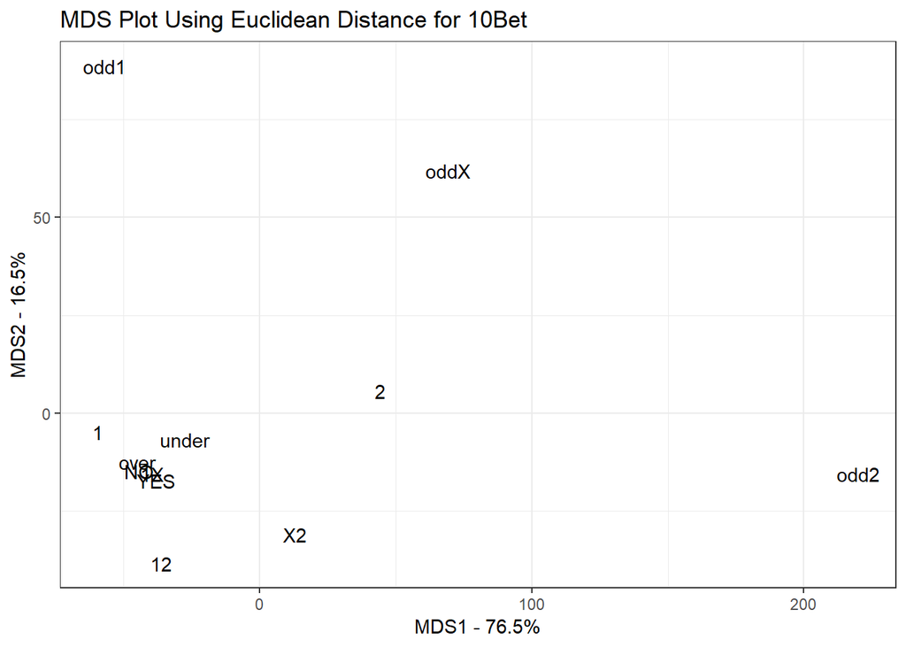

Figure 10 : MDS Plot with Euclidean distance for 10Bet

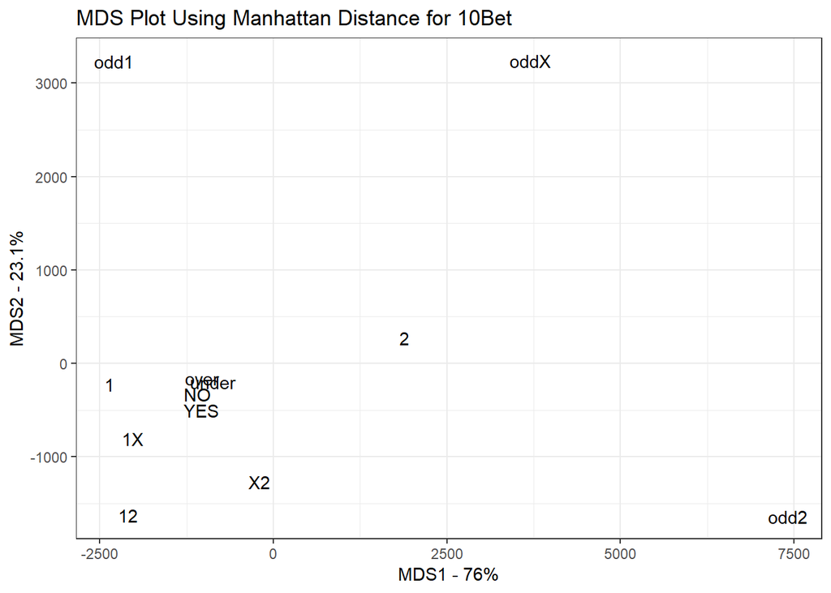

Figure 11 : MDS Plot with Manhattan distance for 10Bet

When we compare these two plots for 10Bey we can see that MDS proportions using Euclidean and Manhattan distances are different. So, plots are not alike. There is not a big difference between the two plots regarding the mapping of the oddtypes.

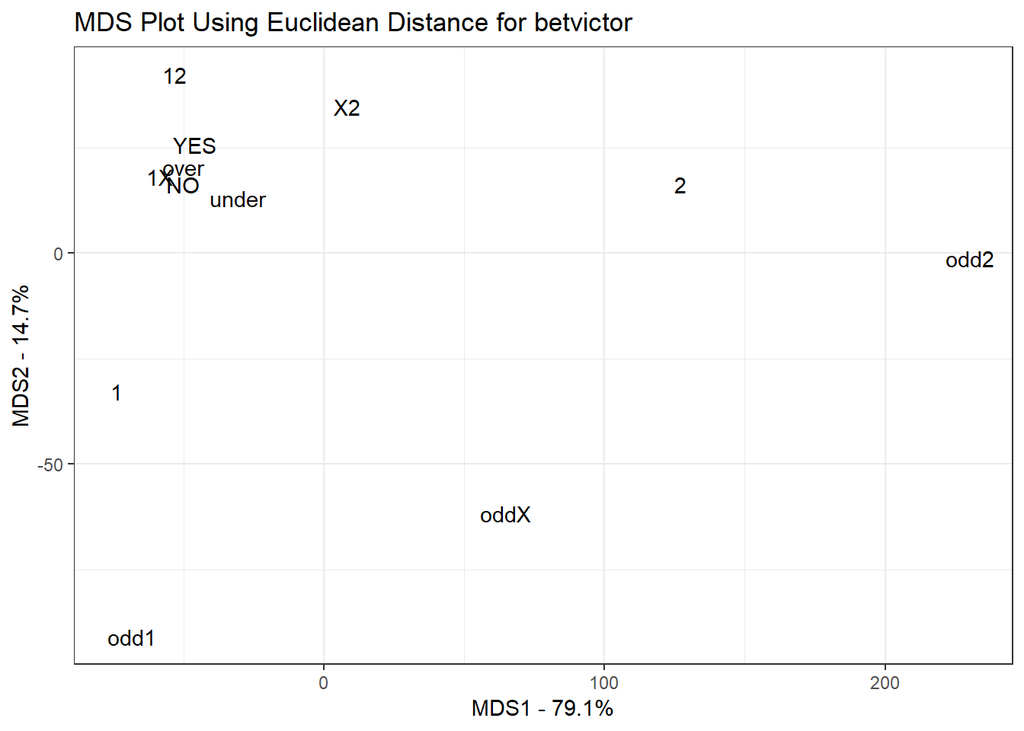

Figure 12 : MDS Plot with Euclidean distance for Betvictor

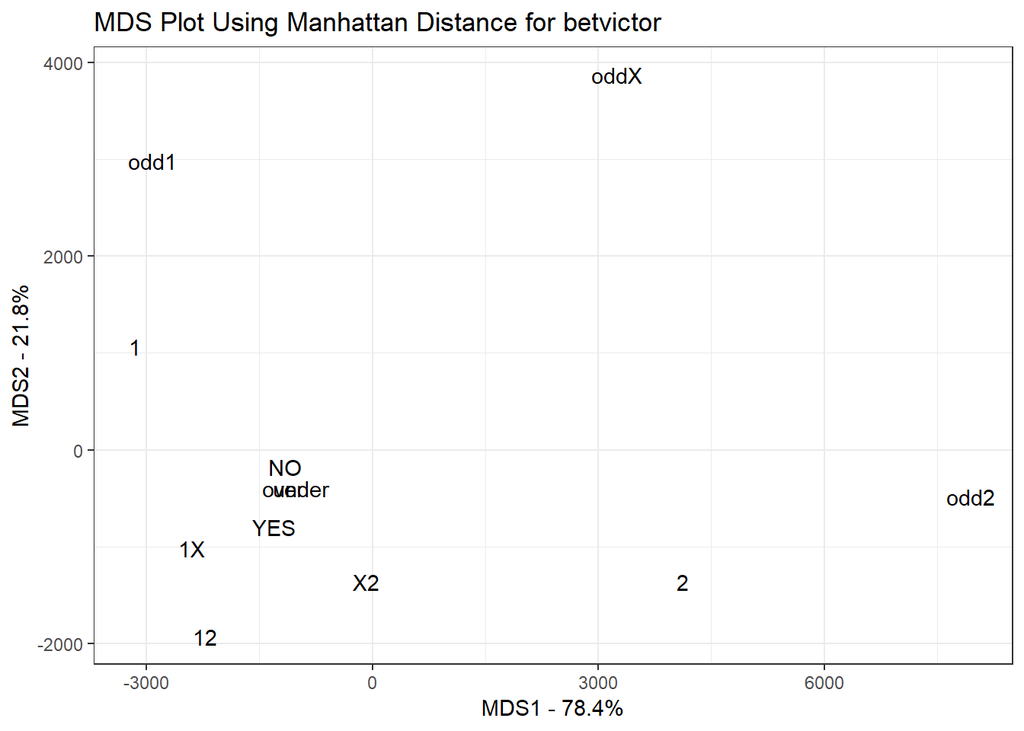

Figure 13 : MDS Plot with Manhattan distance for Betvictor